# Data Challenge Memo

2024-06-03

Group 1 (Ajin, Doliane, Oliver, Reyn)

Professor Hoang

BUAN 4220

01 June 2024

**Data Exploration Project - Memo**

### **Introduction**

A study published in Oxford Academic found that long-term smoking has been shown to contribute to sustained high heart rates and cardiovascular stress. The nicotine found in cigarettes keeps the heart beating faster than normal, and over time, this constant high heart rate can lead to significant cardiovascular diseases. When this occurs, it increases the risk of hypertension as the heart works harder to pump blood through the constricted arteries. This can also contribute to the development of heart failure due to the continuous strain placed on the heart muscle. Importantly, this state can also wear the heart out faster, leading to several other cardiovascular conditions.

Hypertension, also known as high blood pressure, is a factor that determines health by doctors. According to the American College of Cardiology and the American Heart Association, experts divide blood pressure into several different categories based on two different types of pressure readings. The systolic pressure is the top number and the diastolic pressure is the bottom number of overall blood pressure readings. There are four categories: normal blood pressure, elevated blood pressure, stage 1 hypertension, and stage 2 hypertension. A reading of 130 systolic pressure or higher or a reading of 80 diastolic pressure or higher is considered “hypertension” as this signals the first stage of hypertension.

### **The Dataset**

The dataset focuses on smokers’ health, filtered from Hypertension Risk Dataset curated by Md Raihan Kahn. This dataset includes seven variables: age, sex, current smoker status, heart rate, cigarettes per day, and cholesterol levels. According to Kaggle.com, this dataset was updated just one month prior to our analysis, ensuring that we are working with the most recent and relevant information available.

Using this dataset and building on our existing knowledge of the consequences of smoking, we want to explore the detrimental effects of smoking. Our study will focus on how smoking impacts key health metrics such as blood pressure, cholesterol levels, and heart rate. Additionally, we will analyze the demographics of the smokers surveyed to gain a comprehensive understanding of how these factors interact. Through this research we hope to strengthen our current knowledge and potentially uncover new insights regarding smoking habits and their health impacts.

### **Creating Visualizations**

Our first dashboard shows a brief exploration of the data that was collected. The data shows that overall, women could be more likely to become smokers than men. Women were 53.36% of the smokers in this study, compared to men who were 46.64%. However, it seems as though men could be more likely to form more addictive smoking habits than women. On average men smoked 13.4 cigarettes compared to women who smoked 5.5 cigarettes. Smokers also tended to be from the age range of 40-59 years old.

Our second dashboard shows the comparisons of the different genders and ages with the different health factors. For cholesterol and heart rate, it shows that females tended to have higher average levels than men. On the other hand, it shows that men were on average more likely to have hypertension than women.Our third dashboard shows how the amount of cigarettes smoked impacts heart rate and cholesterol. The data shows that on average, both men and women will have an increase in heart rate and cholesterol levels the more cigarettes they smoke. However, the amount of increase is not as big as we thought it would be with our preexisting knowledge of the detrimental effects of smoking. Also, one of the graphs may indicate that age might also be a factor when comparing these health indicators.Our last dashboard shows an overview of the data involving the average cholesterol and heart rates of smokers and non-smokers, categorized by their respective age groups and sexes. Keeping all things constant, we noticed that smokers tend to have a higher average cholesterol and heart rate as opposed to their counterparts.

### **Limitations**

Although evidence from the data supports the findings we are about to discuss, there are limitations to the data. A majority of our data came from the age range of 40-59. This means that the minority of the age range of 30-39 and 60 and older are underrepresented and therefore the usage of the filters must be used carefully. Also, the data shows a correlation to the findings that we will mention, this does not mean that it shows causation. Lastly, some of the participants in this study may have some other underlying health issues that were not mentioned and therefore might skew the data in some type of way.

Unlike much of the research that has been conducted on smoking, our study did not include control variables. The absence of control variables presented both challenges and opportunities for our analysis. This lack limited our ability to establish causal relationships, as it was challenging to attribute the changes in heart rate and cholesterol levels solely to smoking since other lifestyle or genetic factors could have also been at play.

### **Findings**

Despite these limitations, our dataset still allowed us to identify patterns and correlations. By examining how variables such as the number of cigarettes smoked per day and the demographic factors like age and sex influence health outcomes, we were still able to derive meaningful insights. Our analysis still provided us with some evidence that individuals should be advised to avoid smoking. While our dataset did not account for some important factors, such as the control variables, the graphs and data examined clearly illustrate some of the detrimental effects of smoking. For instance, our graphs reveal some trends of elevated heart rates and higher cholesterol levels among the smokers. These findings align with existing information, therefore, reinforcing our pre-existing knowledge and research regarding the health risks associated with smoking.

### **Dashboard #1**

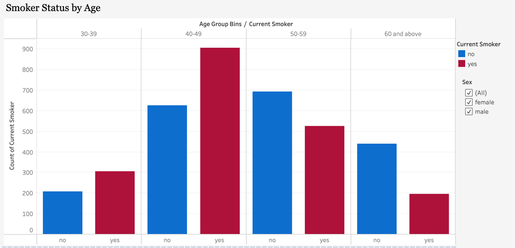

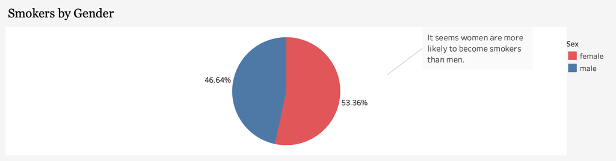

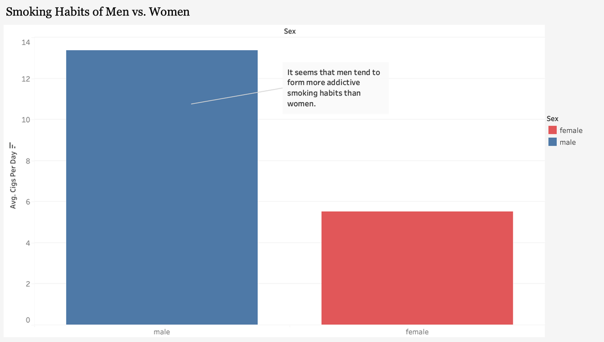

### **Dashboard #2**

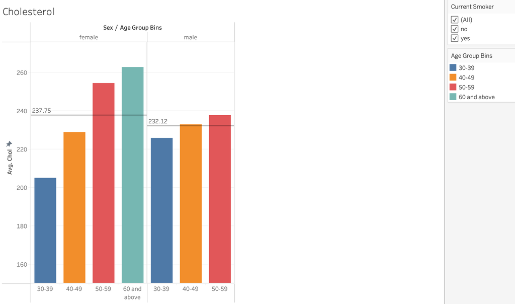

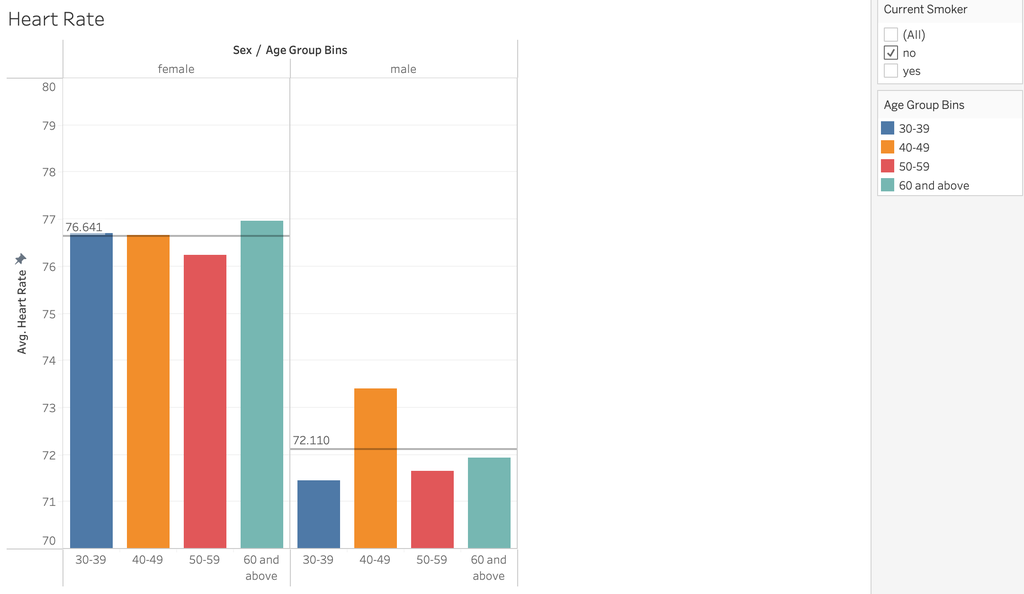

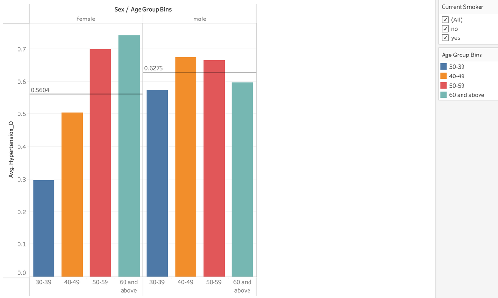

### **Dashboard #3**

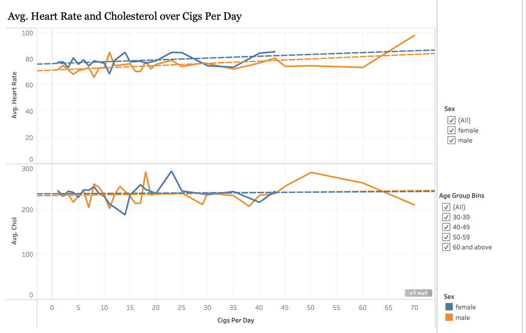

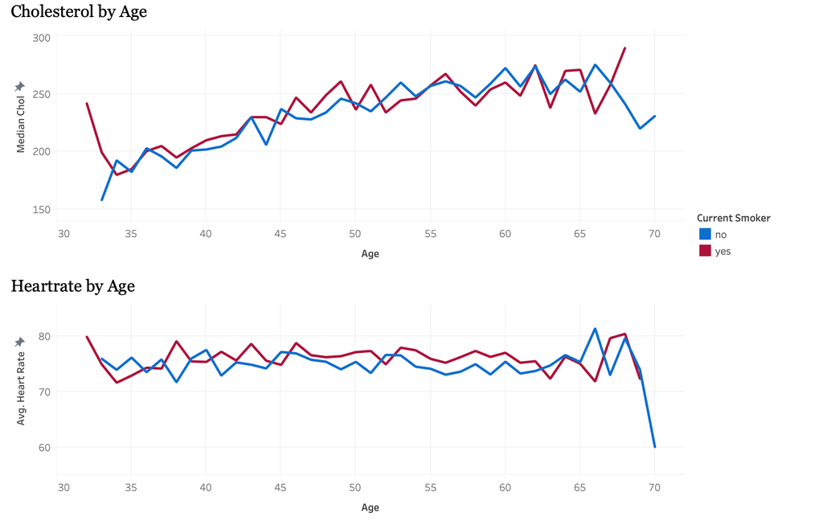

### **Dashboard #4**

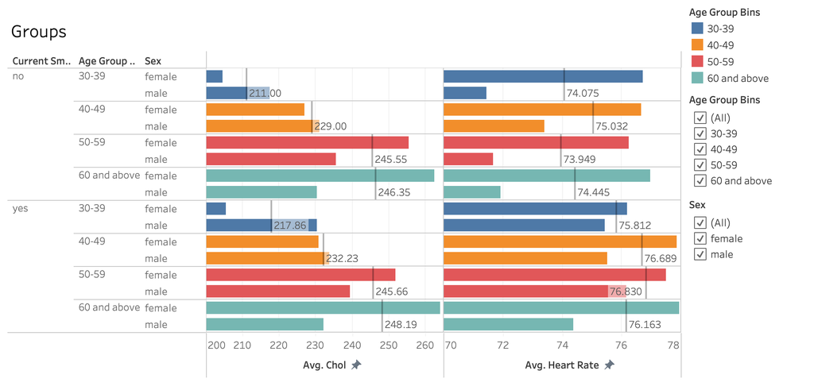